# CW_project1

Chris W

2022-10-16

# Exploratory Data Analysis

#### Importing Weather Data

```r
weather_data <- data.frame(read.csv("NYC_weather_1869_2022.csv"))

#head(weather_data, 5)
```

##### Install Packages

```r
#install.packages("ggplot2")
#install.packages("reshape2")
#install.packages("gridExtra")
#install.packages("ggpmisc")
```

#### Separating Date into Day/Mont/Year columns

```r
weather_data$DATE <- as.Date(weather_data$DATE)

weather_data$YEAR <- as.numeric(format(weather_data$DATE, "%Y"))
weather_data$MONTH<- as.factor(format(weather_data$DATE, "%m"))
weather_data$DAY <- format(weather_data$DATE, "%d")

#head(weather_data, 5)
```

I broke out the date column into separate Day, Month, and Year columns. I did this to make the data easier to manipulate on a month or year level.

#### Subsetting Data and Finding Monthly Averages for Temp, Precip, and Snowfall

```r
weather_100yr <- subset(weather_data, weather_data$YEAR > 1899 & weather_data$YEAR < 2022)

month_tmax_avg <- aggregate(TMAX ~ MONTH + YEAR, weather_data, mean)
month_tmin_avg <- aggregate(TMIN ~ MONTH + YEAR, weather_data, mean)

month_precip_avg <- aggregate(PRCP ~ MONTH + YEAR, weather_data, mean)
colnames(month_precip_avg)[3] <- "PRCP_AVG"

month_precip_total <- aggregate(PRCP ~ MONTH + YEAR, weather_data, sum)
colnames(month_precip_total)[3] <- "PRCP_TOT"

month_snow_avg <- aggregate(SNOW ~ MONTH + YEAR, weather_data, mean)
colnames(month_snow_avg)[3] <- "SNOW_AVG"

month_snow_total <- aggregate(SNOW ~ MONTH + YEAR, weather_data, sum)
colnames(month_snow_total)[3] <- "SNOT_TOT"


monthly_weather <- data.frame(month_tmax_avg,
                                             month_tmin_avg$TMIN,
                                             month_precip_avg$PRCP_AVG,
                                             month_precip_total$PRCP_TOT,
                                             month_snow_avg$SNOW_AVG,
                                             month_snow_total$SNOT_TOT)
colnames(monthly_weather)[4:8] <- c("TMIN", "PRCP_AVG", "PRCP_TOT", "SNOW_AVG", "SNOW_TOT")

monthly_weather_100yr <- subset(monthly_weather, monthly_weather$YEAR > 1899 & monthly_weather$YEAR < 2022)
```

Found the monthly average for TMAX, TMIN, PRCP, and SNOW for all months from 1900-2022. Additionally found the total monthly PRCP and SNOW for all months from 1900 - 2022.

#### Doing the same for Yearly Data

```r
year_tmax_avg <- aggregate(TMAX ~ YEAR, weather_data, mean)
year_tmin_avg <- aggregate(TMIN ~ YEAR, weather_data, mean)

year_precip_avg <- aggregate(PRCP ~ YEAR, weather_data, mean)
colnames(year_precip_avg)[2] <- "PRCP_AVG"

year_precip_total <- aggregate(PRCP ~ YEAR, weather_data, sum)
colnames(year_precip_total)[2] <- "PRCP_TOT"

year_snow_avg <- aggregate(SNOW ~ YEAR, weather_data, mean)
colnames(year_snow_avg)[2] <- "SNOW_AVG"

year_snow_total <- aggregate(SNOW ~ YEAR, weather_data, sum)
colnames(year_snow_total)[2] <- "SNOT_TOT"


yearly_weather <- data.frame(year_tmax_avg,
                             year_tmin_avg$TMIN,
                             year_precip_avg$PRCP_AVG,
                             year_precip_total$PRCP_TOT,
                             year_snow_avg$SNOW_AVG,
                             year_snow_total$SNOT_TOT)
colnames(yearly_weather)[3:7] <- c("TMIN", "PRCP_AVG", "PRCP_TOT", "SNOW_AVG", "SNOW_TOT")


yearly_weather_100yr <- subset(yearly_weather, yearly_weather$YEAR > 1899 & yearly_weather$YEAR < 2022)

library(reshape2)

melt_year_data <- melt(yearly_weather_100yr, id.vars = "YEAR")
```

Found yearly averages for TMAX, TMIN, PRCP, and SNOW. Additionally found the yearly totals for PRCP and SNOW.

### Plotting the Data to Visual Monthly & Yearly Trends

#### Yearly TMAX and TMIN

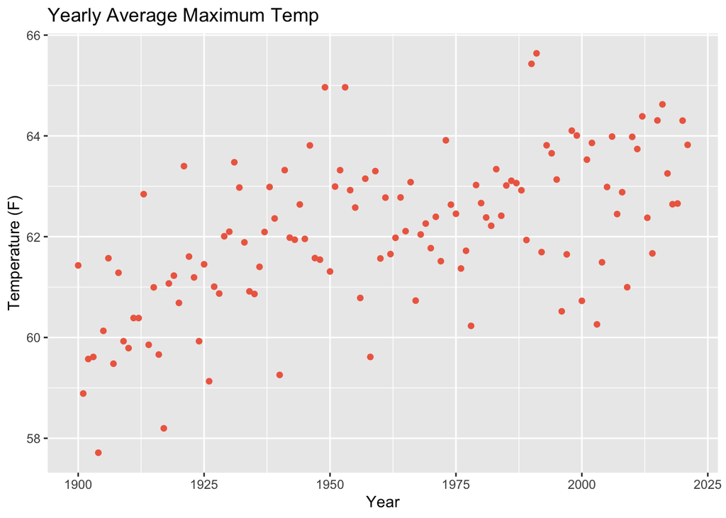

```r
library(ggplot2)

yearly_tmax_scatter <- ggplot(yearly_weather_100yr, aes(x = YEAR, y = TMAX)) +
  geom_point(color = "coral2") +
  labs(x = "Year", y = "Temperature (F)", title = "Yearly Average Maximum Temp")

yearly_tmax_scatter
```

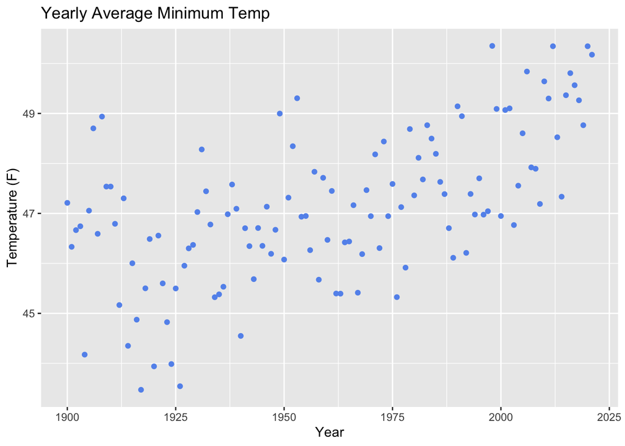

```r
yearly_tmin_scatter <- ggplot(yearly_weather_100yr, aes(x = YEAR, y = TMIN)) +
  geom_point(color = "cornflowerblue") +
  labs(x = "Year", y = "Temperature (F)", title = "Yearly Average Minimum Temp")

yearly_tmin_scatter
```

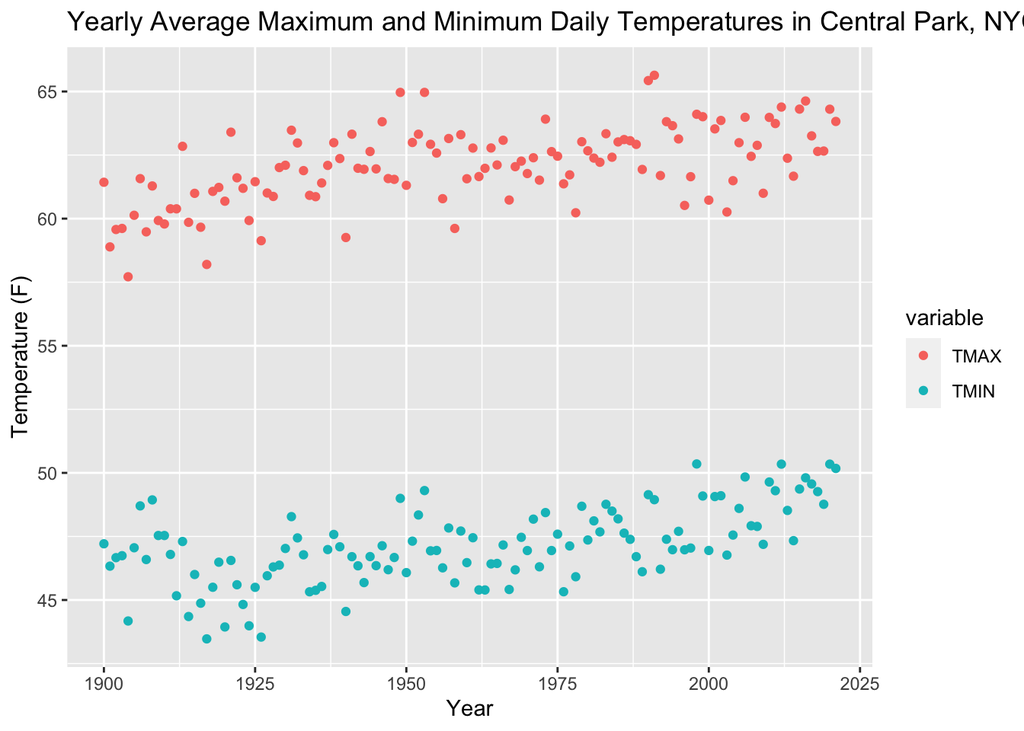

```r
#Combined Tmax - Tmin plot
max_min_sub <- subset(melt_year_data, variable == "TMAX" | variable == "TMIN")

yearly_max_min_scatter <- ggplot(max_min_sub, aes(x = YEAR, y = value, col = variable)) +
  geom_point() +
  labs(x = "Year", y = "Temperature (F)", title = "Yearly Average Maximum and Minimum Daily Temperatures in Central Park, NYC, from 1900-2022")

yearly_max_min_scatter
```

```r
#tmax_scatter <- ggplot(monthly_weather, aes(x = YEAR, y = TMAX, col = MONTH)) +
#  geom_point() +
#  labs(x = "Year", y = "Maximum Daily Temperature (˚F)", title = "Seasonal Max Temperatures in Central Park, NYC, Over Time") +
#  scale_x_continuous(breaks = seq(1900, 2022, 10), minor_breaks = NULL)
  #guides(x = guide_axis(angle = 90, n.dodge = 5))

#tmax_scatter
```

#### Yearly PRCP and SNOW Plots

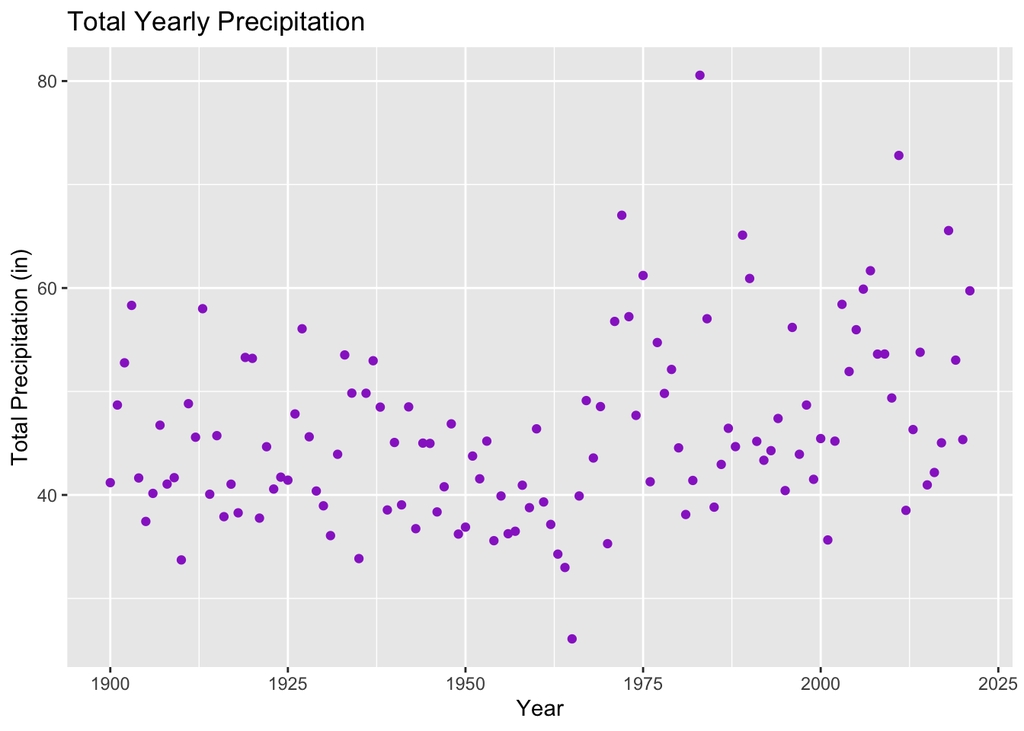

```r
yearly_prcp_scatter <- ggplot(yearly_weather_100yr, aes(x = YEAR, y = PRCP_TOT)) +
  geom_point(color = "darkorchid") +
  labs(x = "Year", y = "Total Precipitation (in)", title = "Total Yearly Precipitation")

yearly_prcp_scatter
```

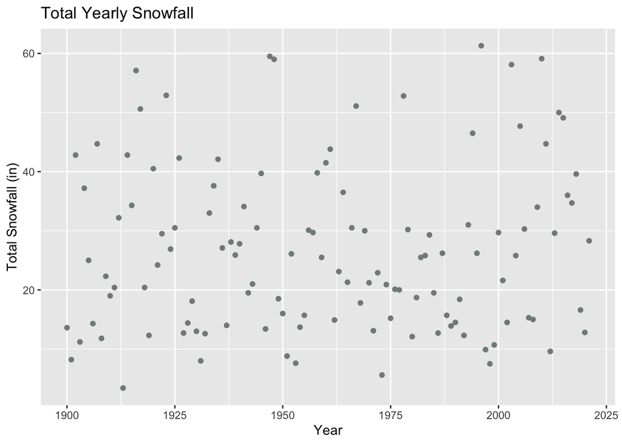

```r
yearly_snow_scatter <- ggplot(yearly_weather_100yr, aes(x = YEAR, y = SNOW_TOT)) +
  geom_point(color = "azure4") +
  labs(x = "Year", y = "Total Snowfall (in)", title = "Total Yearly Snowfall")

yearly_snow_scatter
```

The above code generates 5 plots. One each for TMAX, TMIN, PRCP, and SNOW. Then an additional plot that plots both TMAX and TMIN on the same graph.

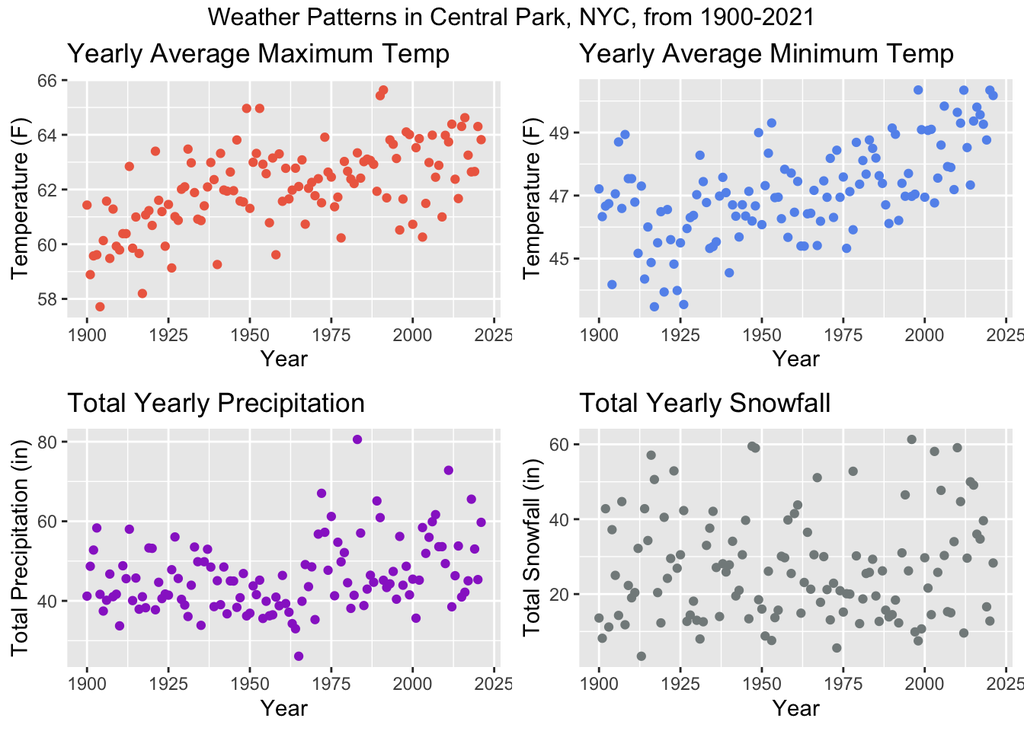

```r
library(gridExtra)

grid.arrange(yearly_tmax_scatter, yearly_tmin_scatter,
             yearly_prcp_scatter, yearly_snow_scatter,
             nrow = 2,
             top = "Weather Patterns in Central Park, NYC, from 1900-2021")
```

# Statistical Analysis

## Question 1:

Are there statistically measurable changes in weather patterns (e.g., temperature and precipitation levels) over time in New York City over this window?

- What statistical test?
- Does this require a linear model?

Using a Linear Regression to estimate the linear trend and statistical significance over time.

### TMAX

```r
#install.packages("gtsummary")

lm_tmax_yr <- lm(TMAX ~ YEAR, data = yearly_weather_100yr)
#lm_tmax_mtyr <- lm(TMAX ~ YEAR + MONTH, data = monthly_weather_100yr)
#lm_tmax_day <- lm(TMAX ~ YEAR, data = weather_100yr)

summary(lm_tmax_yr)
```

```
##
## Call:
## lm(formula = TMAX ~ YEAR, data = yearly_weather_100yr)
##
## Residuals:
##     Min      1Q  Median      3Q     Max
## -2.9255 -0.8266  0.0758  0.7465  3.1896
##
## Coefficients:
##              Estimate Std. Error t value Pr(>|t|)
## (Intercept) 12.566351   6.265722   2.006   0.0472 *
## YEAR         0.025248   0.003195   7.901 1.49e-12 ***
## ---
## Signif. codes:  0 '***' 0.001 '**' 0.01 '*' 0.05 '.' 0.1 ' ' 1
##
## Residual standard error: 1.243 on 120 degrees of freedom
## Multiple R-squared:  0.3422, Adjusted R-squared:  0.3367
## F-statistic: 62.43 on 1 and 120 DF,  p-value: 1.489e-12
```

```r
#summary(lm_tmax_mtyr)
#summary(lm_tmax_day)


coef_tmax_yr <- c(coefficients(lm_tmax_yr), summary(lm_tmax_yr)$adj.r.squared)
coef_tmax_yr
```

```
## (Intercept)        YEAR
## 12.56635065  0.02524803  0.33672842
```

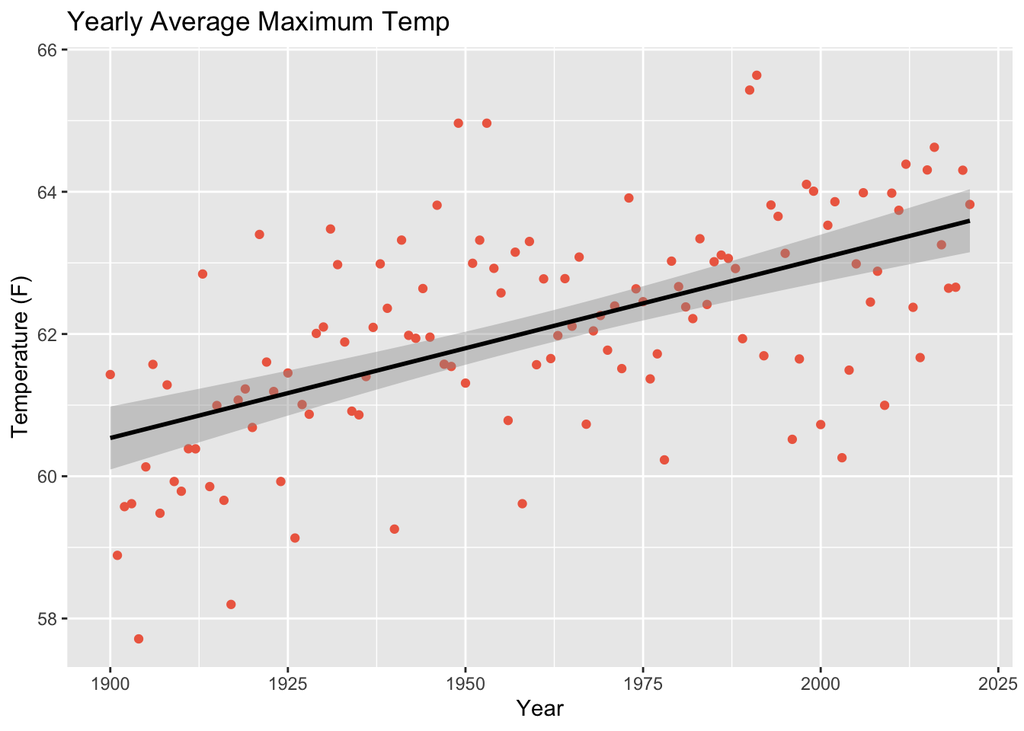

```r
library(ggpmisc)
yr_tmax_scatter_line <- yearly_tmax_scatter+
  stat_smooth(method = "lm",
              formula = y ~ x,
              geom = "smooth",
              color = "black",
              show.legend = F)

yr_tmax_scatter_line
```

The regression line added to the yearly TMAX scatterplot. The slope of the line is 0.025248. This implies the average daily maximum temperature is increasing by 0.025248 degrees F per year, or by about 0.2524803 degrees F per decade.

### TMIN

```r
lm_tmin_yr <- lm(TMIN ~ YEAR, data = yearly_weather_100yr)
summary(lm_tmin_yr)
```

```
##
## Call:
## lm(formula = TMIN ~ YEAR, data = yearly_weather_100yr)
##
## Residuals:
##     Min      1Q  Median      3Q     Max
## -2.7039 -0.9296  0.0013  0.9041  3.1525
##
## Coefficients:
##              Estimate Std. Error t value Pr(>|t|)
## (Intercept) -3.148966   6.082945  -0.518    0.606
## YEAR         0.025647   0.003102   8.267 2.13e-13 ***
## ---
## Signif. codes:  0 '***' 0.001 '**' 0.01 '*' 0.05 '.' 0.1 ' ' 1
##
## Residual standard error: 1.207 on 120 degrees of freedom
## Multiple R-squared:  0.3629, Adjusted R-squared:  0.3576
## F-statistic: 68.34 on 1 and 120 DF,  p-value: 2.134e-13
```

```r
#lm_tmin_day <- lm(TMIN ~ YEAR, data = weather_100yr)
#summary(lm_tmin_day)


#coef_tmin_yr <- coefficients(lm_tmin_yr)
#coef_tmin_day <- coefficients(lm_tmin_day)
```

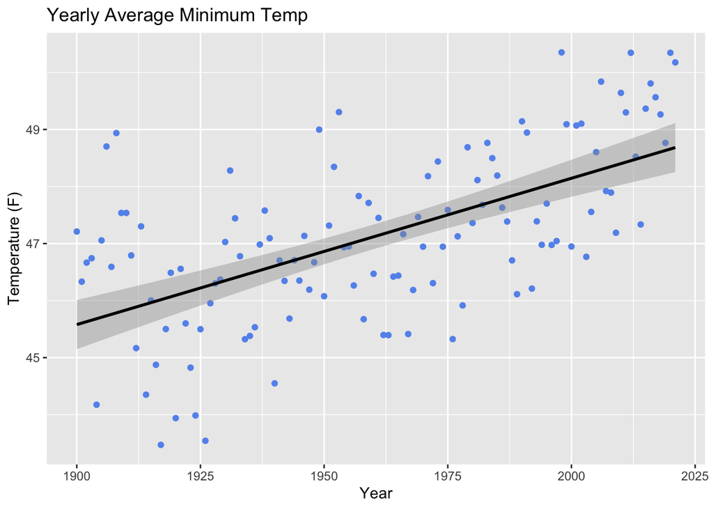

```r
yr_tmin_scatter_line <- yearly_tmin_scatter +
  stat_smooth(method = "lm",
              formula = y ~ x,
              geom = "smooth",
              color = "black",
              show.legend = F)

yr_tmin_scatter_line
```

### PRCP

```r
lm_prcp_yr <- lm(PRCP_TOT ~ YEAR, data = yearly_weather_100yr)
lm_prcp_month <- lm(PRCP_TOT ~ YEAR + MONTH, data = monthly_weather_100yr)
lm_prcp_avg <- lm(PRCP_AVG ~ YEAR + MONTH, data = monthly_weather_100yr)

lm_prcp_day <- lm(PRCP ~ YEAR, data = weather_100yr)
summary(lm_prcp_month)
```

```
##
## Call:
## lm(formula = PRCP_TOT ~ YEAR + MONTH, data = monthly_weather_100yr)
##
## Residuals:
##     Min      1Q  Median      3Q     Max
## -4.4773 -1.4689 -0.2807  1.0401 14.1927
##
## Coefficients:
##              Estimate Std. Error t value Pr(>|t|)
## (Intercept) -8.799287   3.096315  -2.842 0.004548 **
## YEAR         0.006249   0.001576   3.965 7.71e-05 ***
## MONTH02     -0.167787   0.271956  -0.617 0.537356
## MONTH03      0.585820   0.271956   2.154 0.031397 *
## MONTH04      0.427869   0.271956   1.573 0.115867
## MONTH05      0.442131   0.271956   1.626 0.104222
## MONTH06      0.343115   0.271956   1.262 0.207276
## MONTH07      0.870820   0.271956   3.202 0.001394 **
## MONTH08      0.989262   0.271956   3.638 0.000285 ***
## MONTH09      0.481721   0.271956   1.771 0.076718 .
## MONTH10      0.335082   0.271956   1.232 0.218105
## MONTH11      0.073443   0.271956   0.270 0.787158
## MONTH12      0.339180   0.271956   1.247 0.212530
## ---
## Signif. codes:  0 '***' 0.001 '**' 0.01 '*' 0.05 '.' 0.1 ' ' 1
##
## Residual standard error: 2.124 on 1451 degrees of freedom
## Multiple R-squared:  0.03234,    Adjusted R-squared:  0.02434
## F-statistic: 4.042 on 12 and 1451 DF,  p-value: 3.291e-06
```

```r
summary(lm_prcp_yr)
```

```
##
## Call:
## lm(formula = PRCP_TOT ~ YEAR, data = yearly_weather_100yr)
##
## Residuals:
##     Min      1Q  Median      3Q     Max
## -20.398  -5.593  -1.475   4.511  32.723
##
## Coefficients:
##               Estimate Std. Error t value Pr(>|t|)
## (Intercept) -100.87078   42.45573  -2.376  0.01909 *
## YEAR           0.07499    0.02165   3.463  0.00074 ***
## ---
## Signif. codes:  0 '***' 0.001 '**' 0.01 '*' 0.05 '.' 0.1 ' ' 1
##
## Residual standard error: 8.422 on 120 degrees of freedom
## Multiple R-squared:  0.09088,    Adjusted R-squared:  0.0833
## F-statistic:    12 on 1 and 120 DF,  p-value: 0.0007399
```

```r
summary(lm_prcp_avg)
```

```
##
## Call:
## lm(formula = PRCP_AVG ~ YEAR + MONTH, data = monthly_weather_100yr)
##
## Residuals:
##      Min       1Q   Median       3Q      Max
## -0.14452 -0.04831 -0.00931  0.03454  0.45770
##
## Coefficients:
##               Estimate Std. Error t value Pr(>|t|)
## (Intercept) -2.889e-01  1.014e-01  -2.849 0.004446 **
## YEAR         2.042e-04  5.162e-05   3.955 8.02e-05 ***
## MONTH02      4.937e-03  8.907e-03   0.554 0.579456
## MONTH03      1.890e-02  8.907e-03   2.122 0.034030 *
## MONTH04      1.797e-02  8.907e-03   2.018 0.043763 *
## MONTH05      1.426e-02  8.907e-03   1.601 0.109526
## MONTH06      1.515e-02  8.907e-03   1.701 0.089172 .
## MONTH07      2.809e-02  8.907e-03   3.154 0.001644 **
## MONTH08      3.191e-02  8.907e-03   3.583 0.000351 ***
## MONTH09      1.977e-02  8.907e-03   2.220 0.026596 *
## MONTH10      1.081e-02  8.907e-03   1.214 0.225098
## MONTH11      6.160e-03  8.907e-03   0.692 0.489258
## MONTH12      1.094e-02  8.907e-03   1.228 0.219480
## ---
## Signif. codes:  0 '***' 0.001 '**' 0.01 '*' 0.05 '.' 0.1 ' ' 1
##
## Residual standard error: 0.06956 on 1451 degrees of freedom
## Multiple R-squared:  0.02645,    Adjusted R-squared:  0.0184
## F-statistic: 3.285 on 12 and 1451 DF,  p-value: 0.0001042
```

```r
coef_prcp_yr <- c(coefficients(lm_prcp_yr), summary(lm_prcp_yr)$r.square)
coef_prcp_yr
```

```
##   (Intercept)          YEAR
## -100.87078375    0.07499156    0.09087955
```

```r
#coef_prcp_day <- coefficients(lm_tmax_day)
#coef_table_prcp <- cbind(coef_prcp_day, coef_prcp_yr)
#coef_table_prcp
```

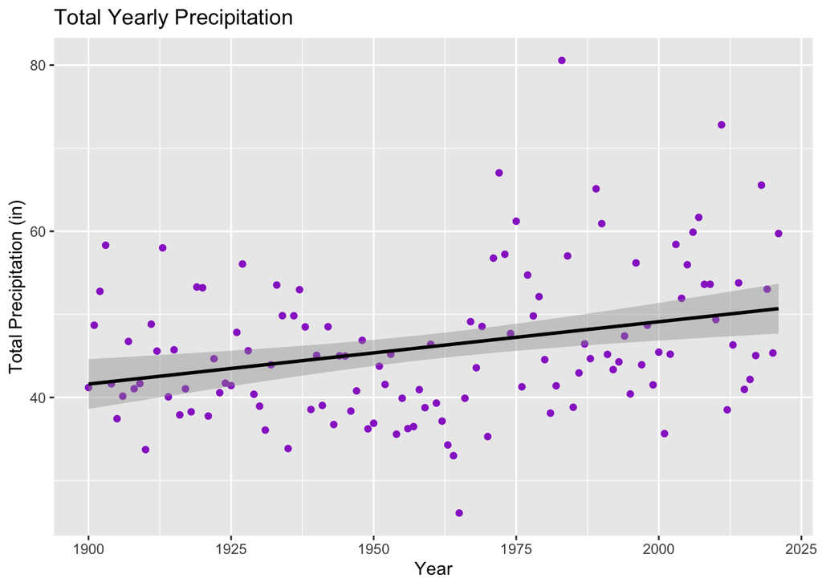

```r
yr_prcp_scatter_line <- yearly_prcp_scatter+
  stat_smooth(method = "lm",
              formula = y ~ x,
              geom = "smooth",
              color = "black",
              show.legend = F) +
  labs(title = "Total Yearly Precipitation")


yr_prcp_scatter_line
```

### SNOW

```r
lm_snow_yr <- lm(SNOW_TOT ~ YEAR, data = yearly_weather_100yr)
summary(lm_snow_yr)
```

```
##
## Call:
## lm(formula = SNOW_TOT ~ YEAR, data = yearly_weather_100yr)
##
## Residuals:
##     Min      1Q  Median      3Q     Max
## -22.363 -11.884  -1.579   7.985  33.787
##
## Coefficients:
##              Estimate Std. Error t value Pr(>|t|)
## (Intercept) -14.57845   70.53414  -0.207    0.837
## YEAR          0.02109    0.03597   0.586    0.559
##
## Residual standard error: 13.99 on 120 degrees of freedom
## Multiple R-squared:  0.002856,   Adjusted R-squared:  -0.005454
## F-statistic: 0.3437 on 1 and 120 DF,  p-value: 0.5588
```

```r
coef_snow_yr <- coefficients(lm_snow_yr)
coef_snow_yr
```

```
##  (Intercept)         YEAR
## -14.57845358   0.02108809
```

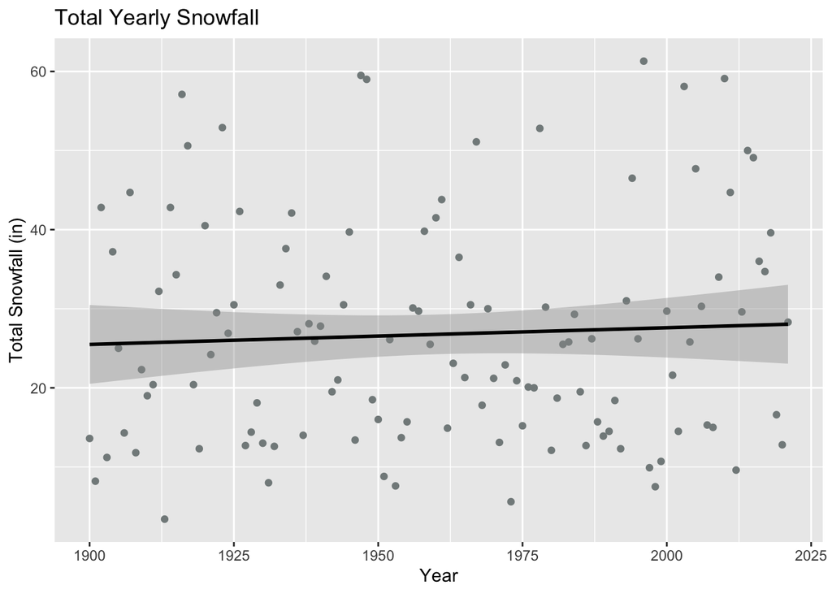

```r
yr_snow_scatter_line <- yearly_snow_scatter+
  stat_smooth(method = "lm",
              formula = y ~ x,
              geom = "smooth",
              color = "black",
              show.legend = F)+
  labs(title = "Total Yearly Snowfall")


yr_snow_scatter_line
```

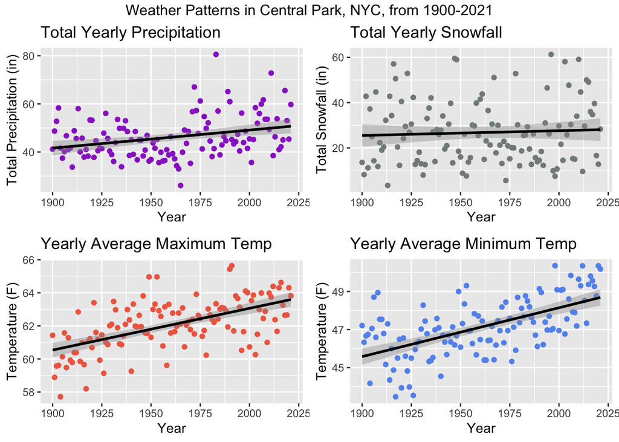

```r
library(gridExtra)

grid.arrange(yr_prcp_scatter_line, yr_snow_scatter_line,
             yr_tmax_scatter_line, yr_tmin_scatter_line,
             nrow = 2,
             top = "Weather Patterns in Central Park, NYC, from 1900-2021")
```